# Lab 6 - Phys 434

## 11/22/21

```python
import numpy as np
import matplotlib
import matplotlib.pyplot as plt
import scipy
from scipy import stats

import pickle

plt.rcParams["figure.figsize"] = (15,8)
```

# Problem 1

```python
x = np.linspace(0,200,201)
bkgd = stats.poisson.pmf(x,mu=100)
```

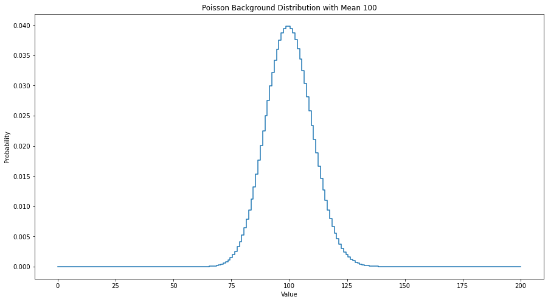

```python
plt.step(x,bkgd,where='mid')
plt.title('Poisson Background Distribution with Mean 100')
plt.xlabel('Value')
plt.ylabel('Probability')
```

```python
prob = stats.norm.cdf(5)

stats.poisson.ppf(prob,mu=100)
```

```
154.0
```

# Problem 2

Firstly I replotted the original poisson background, using random variates this time:

```python
bkgd = stats.poisson.rvs(mu=100,size=1000000)
```

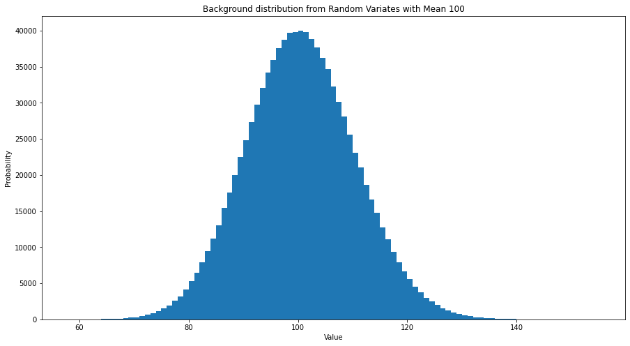

```python
plt.hist(bkgd,bins=max(bkgd)-min(bkgd))
plt.title('Background distribution from Random Variates with Mean 100')
plt.xlabel('Value')
plt.ylabel('Probability');
```

## Now inject a signal of known strength. You will want to make your signal moderately strong, say somewhere in the 8-30σ range. Inject this signal into your background data many times.

```python
#10 sigma value to add signal

200 - stats.poisson.ppf(stats.norm.sf(10),mu=100)
```

```
181.0
```

```python
signal_size = 1000
signal = [0]*(1000000-signal_size)
for i in range(signal_size):
    signal.append(181)
```

## a) Histogram how bright the observed signal appears to be, and discuss it's shape. Say in words what this histogram is telling you.

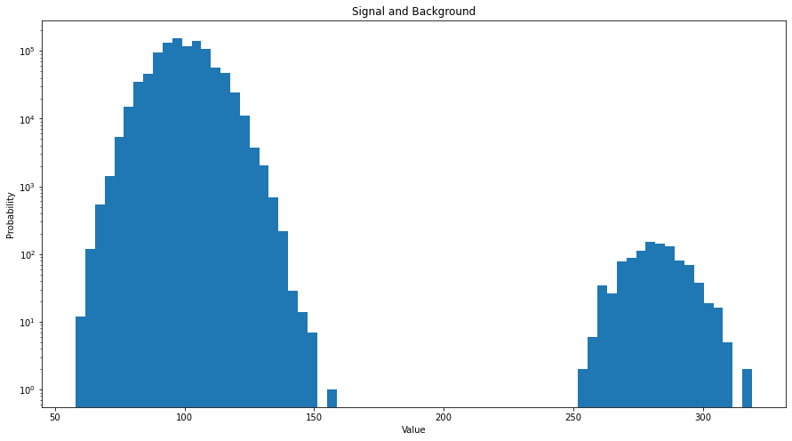

```python
data = signal + bkgd
plt.hist(data,bins=70)
plt.yscale('log')
plt.title('Signal and Background')
plt.xlabel('Value')
plt.ylabel('Probability');
```

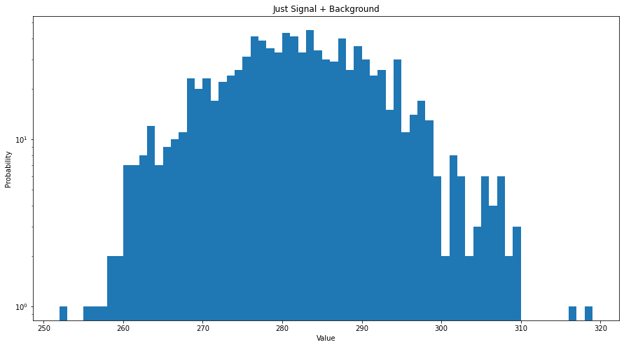

```python
signal_data = data[-signal_size:]
plt.hist(signal_data,bins=max(signal_data) - min(signal_data))
plt.yscale('log')
plt.title('Just Signal + Background')
plt.xlabel('Value')
plt.ylabel('Probability');
```

This is clearly still a poisson distributed signal. I can see this both visually and mathematically. Visually, the histogram of the observed signal is clearly gaussian in shape and discrete, so it must be poisson. Mathematically, I know that I added random variates to an already poisson signal. This only produces a shift in the mean of the data, but not the distribution of the data, so it is still poisson.

## b) Is your observed signal biased? (e.g. is the observed value equally likely to be stronger or weaker than the true injected signal?) Is it symmetric?

It is biased and symmetric. Since the data is being added to the background, it is much more likely to be stronger than the true injected signal, and in this case, all of the data is. Since the added data is uniformly distributed around the value 181, it only produces a poisson distribution around that number, which is symmetric.

# Problem 3

## Now make a suite of injected signals. You will want to have a range of injected signal strengths, starting at zero and extending well above 5σ (30σ or more). You will want to follow the work you did for Homework 5 very closely.

## a) Clearly state what you are simulating, and make a 2D histogram of injected signal vs. observed data

So now I am simulating if a bunch of random noise was thrown into my background distribution. For every point of injected signal, there will be a distribution of observed signal around that that is poisson.

```python
stats.norm.sf(30)
```

```
4.906713927147908e-198
```

```python
x = np.linspace(0,1000,1001)
dist = stats.poisson.pmf(x,mu=100)

sigma35 = np.where(dist<stats.norm.sf(35),x,0)
sigma35 = sigma35[sigma35 != 0]
```

```python
sigma35[0]
```

```
621.0
```

```python
new_signal = stats.randint.rvs(0,sigma35[0],size=1000000)
```

```python
new_signal
```

```
array([575, 191, 127, ..., 158, 493, 197])
```

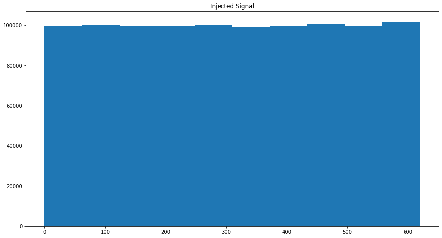

```python
plt.hist(new_signal)
plt.title('Injected Signal');
```

```python
new_data = bkgd + new_signal
```

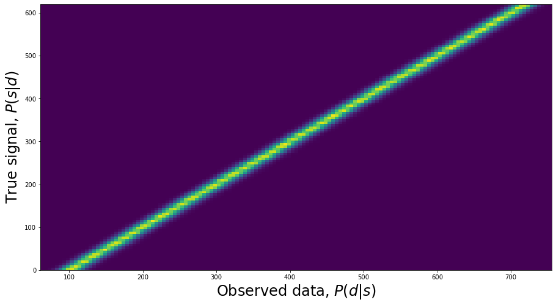

```python
xrange = max(new_data) - min(new_data)
yrange = max(new_signal) - min(new_data)

hist_data,xbins,ybins,extra = plt.hist2d(new_data,new_signal, bins = (int(xrange/5),int(yrange/5)))

plt.ylabel('True signal, $P(s|d)$', fontsize = 24)
plt.xlabel('Observed data, $P(d|s)$', fontsize = 24)
```

## b) For the same injected signal power as in problem 2, show that you get the same answer.

```python
hist_data.shape
```

```
(139, 111)
```

```python
#here my ybin spacing is:
(max(ybins) - min(ybins)) / len(ybins)
```

```
5.535714285714286
```

```python
idx = int(181/5.5)
idx
```

```
32
```

```python
ybins[32]
```

```
178.73873873873873
```

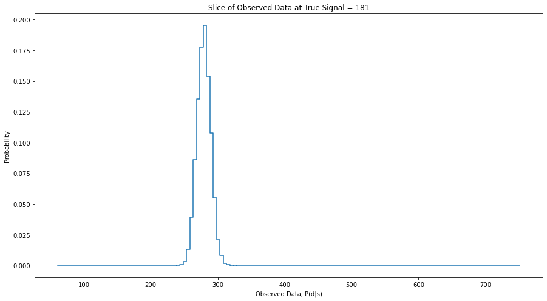

```python
plt.step(xbins[:-1],hist_data[:,idx]/sum(hist_data[:,idx]),where='mid')
plt.title('Slice of Observed Data at True Signal = 181')
plt.xlabel('Observed Data, P(d|s)')
plt.ylabel('Probability')
```

This is showing that the observed data for a true signal of 181 will be centered on around 281 due to the shift when added to the background. This is exactly what I showed in Problem 2.

## c) Now reverse the problem, select an observed data value (pick something quite a bit stronger than 5σ) and create a 1D histogram of the true signal probability given the observed data. Describe the meaning of this histogram.

For this I will choose a sigma value of 15 which I found to be a 284.

```python
x = np.linspace(0,500,501)
dist = stats.poisson.pmf(x,mu=100)

sigma15 = np.where(dist<stats.norm.sf(15),x,0)
sigma15 = sigma15[sigma15 != 0]
sigma15[0]
```

```
284.0
```

```python
(max(xbins) - min(xbins))/len(xbins)
```

```
4.964285714285714
```

```python
idx = int((284-min(xbins))/5)
idx
```

```
44
```

```python
xbins[idx]
```

```
281.0
```

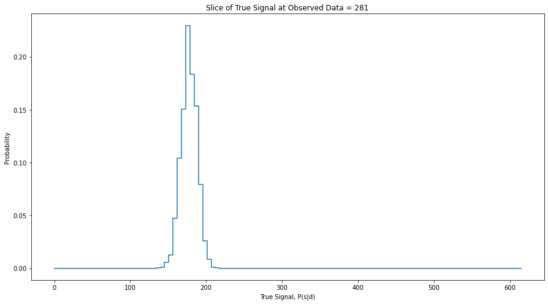

```python
plt.step(ybins[:-1],hist_data[idx,:]/sum(hist_data[idx,:]))
plt.title('Slice of True Signal at Observed Data = 281')
plt.xlabel('True Signal, P(s|d)')
plt.ylabel('Probability')
```

## d) For your observed signal, what is the 1σ uncertainty on the true signal strength?

this is the same as standard deviation:

```python
the_data = []
total = sum(hist_data[idx,:])
for i in range(len(ybins[1:])):
    for a in range(int(hist_data[idx,i]*100)):
        the_data.append(ybins[i])
```

```python
mean = np.mean(the_data)
mean
```

```
180.38998685956912
```

```python
std = np.std(the_data)
std
```

```
10.34586563636211
```

So the 1 sigma uncertainty on the true signal strength is at:

```python
mean+std
```

```
190.73585249593123
```

```python
mean-std
```

```
170.04412122320701
```

## e) Discuss the answer to part d in some depth. Is it symmetric? Is it biased? Does this make sense?

This means that there is a 67% chance that our observed signal is $\pm 10$ from the true signal that is observed signal minus background. This makes sense because both the injected signal and background vary. So there are many injected signals that could produce the same value of observed data, and vice versa. It is symmetric, roughly, because the poisson distribution the data is pulled from has a high mean (100) and nears to a gaussian distribution due to this and the central limit theorem. It is also biased, because of the shift in data.